# Effect on Tooth Growth of Vitamin C with Different Supplement Types and Dosages

Amiel Sy

July 1, 2016

## Overview

In this project we are going to analyze the ToothGrowth data from the datasets package in R which describes the effect of vitamin C on tooth growth of guinea pigs.

The ToothGrowth dataset consists of 60 rows and 3 columns:

len: Tooth length in millimeters  
supp: Supplement type- VC (Vitamin C) or OJ (Orange Juice)  
dose: Dose in milligrams (0.5, 1, or 2)

There are 10 guinea pigs for each combination of dose and supp.

```r
with(ToothGrowth, table(dose, supp))
```

```
##      supp
## dose  OJ VC
##   0.5 10 10
##   1   10 10
##   2   10 10
```

## Exploratory data analysis

#### Effect of Supplement Type on Length

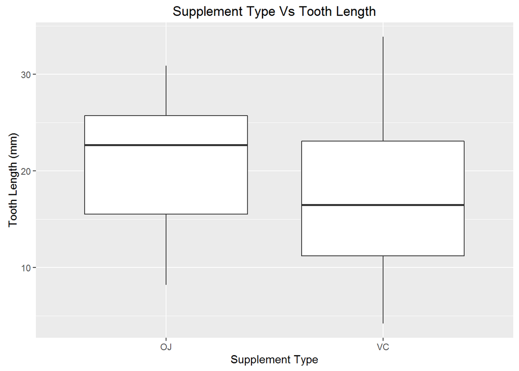

```r
library(ggplot2)
gsupp <- ggplot(ToothGrowth, aes(supp, len)) +
  geom_boxplot() +
  xlab('Supplement Type') +
  ylab('Tooth Length (mm)') +
  ggtitle('Supplement Type Vs Tooth Length')
gsupp
```

From the graph above, we can see that Orange Juice has a higher tooth growth compared to Vitamin C.

#### Effect of Dosage on Length

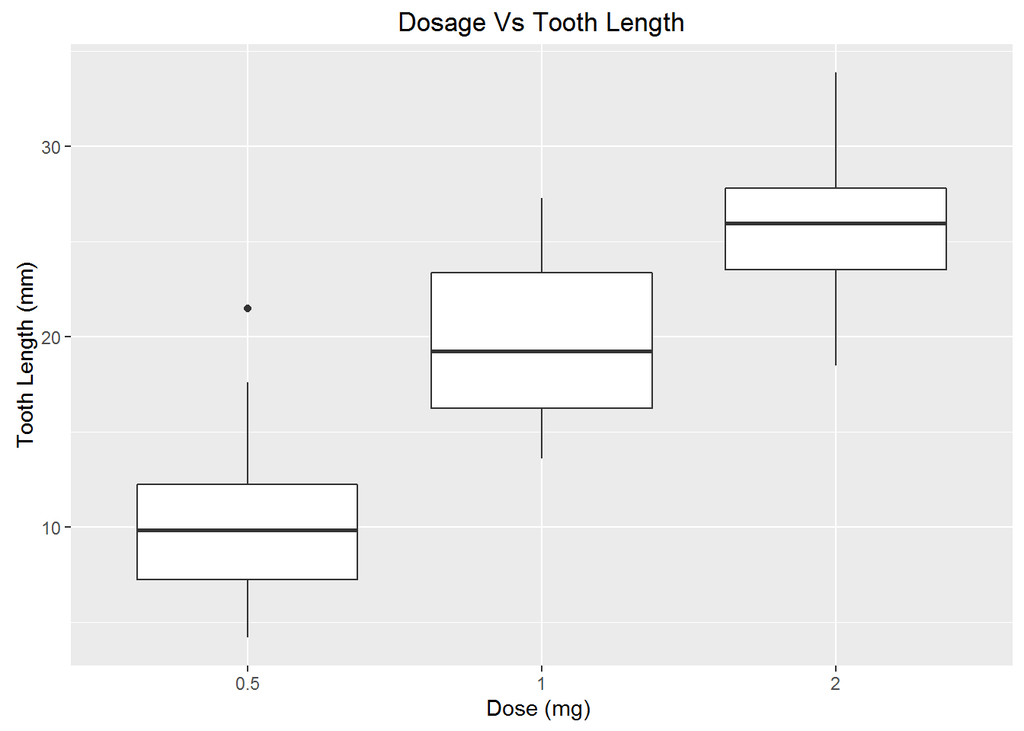

```r
library(ggplot2)
gdose <- ggplot(ToothGrowth, aes(as.factor(dose), len)) +
  geom_boxplot() +
  xlab('Dose (mg) ') +
  ylab('Tooth Length (mm)') +
  ggtitle('Dosage Vs Tooth Length')
gdose
```

From the graph above, we can see that higher dosage results in higher tooth growth.

## Hypothesis Test

### Assumptions

The assumptions we make are:  
1. Independence of the observations  
2. Observations come from a nearly normal distribution.

We need these assumptions so that we can use the T-test. The null hypothesis for all the test below is that the two groups have equal tooth growth.

### Differences in Supplement Types

We check if there is a significant difference in tooth length between guinea pigs who take oranje juice and guinea pigs who take vitamin C. We use t-test because sample is small and we don’t assume equal variances. We used a two-tailed test and we make alpha=0.05.

```r
t.test(len ~ supp, ToothGrowth, var.equal = FALSE)$p.value
```

```
## [1] 0.06063451
```

Since p-value>0.05, we failed to reject the null hypothesis, though it is worth noting that we can reject the null hypothesis in a one-tailed test.

### Differences in Dosage

We check if there is a significant difference in tooth length between guinea pigs who take different doses. We use t-test in each pair of dosage with a two-tailed test using var.equal=FALSE, and alpha=0.05.

#### Test between 1mg and 2mg Dosage

```r
t.test(ToothGrowth$len[ToothGrowth$dose == 2],
       ToothGrowth$len[ToothGrowth$dose == 1], var.equal = FALSE)$p.value
```

```
## [1] 1.90643e-05
```

```r
t.test(ToothGrowth$len[ToothGrowth$dose == 2],
       ToothGrowth$len[ToothGrowth$dose == .5], var.equal = FALSE)$p.value
```

```
## [1] 4.397525e-14
```

```r
t.test(ToothGrowth$len[ToothGrowth$dose == .5],
       ToothGrowth$len[ToothGrowth$dose == 1], var.equal = FALSE)$p.value
```

```
## [1] 1.268301e-07
```

Since p-value<0.05 for all test, we reject all the null hypothesis, and accept that there is significant difference in tooth length between dose= 2, 1, and 0.5.

# Conclusions

We were able to show that the observed difference of tooth length across supplement types is statistically equal to zero, though increasing sample size might be able to change this.

We were able to show that the observed difference of tooth length across different dosages is statistically not equal to zero.